# Main 1

```python
!pip install networkx
!pip install folium
import requests
from bs4 import BeautifulSoup
import datetime
import pandas as pd
import numpy as np
from matplotlib import pyplot as plt
import math
import pickle # pickle is used to save and open files
```

```python
res = requests.get("https://www.transtats.bts.gov/DatabaseInfo.asp?QO_VQ=EFI&QO_anzr=Nv4yv0r%20b4vtv0%20n0q%20Qr56v0n6v10%20f748rB%20(QOEO)")
res
```

[output not shown]

[output cut: 86 more lines]

[output not shown]

Load Data

```python
data = pd.read_csv("T_DB1B_MARKET_2023.csv")
```

Filter out flights that are less than $50 as recommended by the database. These flights do not have a base fare, but instead only contain taxes and fees.

```python
m,n = data.shape
deleteIdx = pd.Series(data['MARKET_FARE']<50)
data = data[~deleteIdx]
```

Now I want to clean the data so that I have the average cost for each flight for a unique origin and desitnation.

```python
dataC = data.groupby(['ORIGIN', 'DEST']).agg({'MARKET_FARE': 'mean'}).reset_index()
m,n = dataC.shape
dataC.columns = ['IATA code origin', 'IATA code destination','MARKET_FARE']
```

```python
dataC[:20]
```

|  | IATA code origin | IATA code destination | MARKET_FARE |
| --- | --- | --- | --- |
| 0 | ABE | ABI | 490.350000 |
| 1 | ABE | ABQ | 360.833000 |
| 2 | ABE | ABY | 204.230000 |
| 3 | ABE | AEX | 215.100000 |
| 4 | ABE | AGS | 257.102727 |
| 5 | ABE | AMA | 475.500000 |
| 6 | ABE | ANC | 202.750000 |
| 7 | ABE | ASE | 324.000000 |
| 8 | ABE | ATL | 206.892364 |
| 9 | ABE | ATW | 278.828235 |
| 10 | ABE | AUS | 263.594500 |
| 11 | ABE | AVL | 241.946000 |
| 12 | ABE | AZO | 184.833333 |
| 13 | ABE | BGR | 117.000000 |
| 14 | ABE | BHM | 272.711034 |
| 15 | ABE | BMI | 297.333333 |
| 16 | ABE | BNA | 182.327586 |
| 17 | ABE | BOI | 317.060000 |
| 18 | ABE | BOS | 181.630000 |
| 19 | ABE | BQK | 433.250000 |

Now I would like to visualize the data a bit. The spread of the fare costs looks like

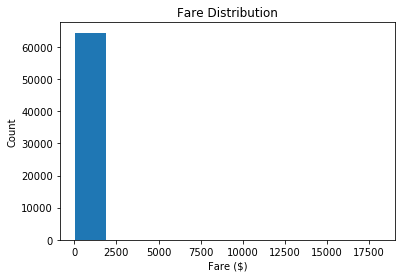

```python
plt.figure()
bins = 10
plt.hist(dataC['MARKET_FARE'])
plt.title('Fare Distribution')
plt.xlabel('Fare ($)')
plt.ylabel('Count')
plt.show()
```

The histogram is skewed so apply log transform

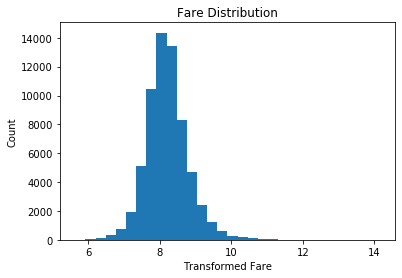

```python
plt.figure()
bins = 30
plt.hist(np.log2(dataC["MARKET_FARE"]),bins)
plt.title('Fare Distribution')
plt.xlabel('Transformed Fare')
plt.ylabel('Count')
plt.show()
```

Interesting enough, we see a normal distribution in the transformed data.

The created directed graph has 438 nodes which makes it difficult to visualize.

```python
import folium
```

```python
airport_map = folium.Map(location=[48.5,-110],zoom_start=3.2)
```

```python
# load latitude/longitude data and format table
originLocation = pd.read_csv("GlobalAirportDatabase.txt",sep=':',header=None)
originLocation.columns = ['ICAO code','IATA code origin','Name','City','Country','Latitude Degrees','Latitude Minutes','Latitude Seconds','Latitude Direction','Longitude Degrees','Longitude Minutes','Longitude Seconds','Longitude Direction','Altitude','Latitude Origin','Longitude Origin']
```

```python
# now we only want airports in the United States, so we can filter the location data
originLocation = originLocation[originLocation['Country']=='USA'].reset_index()
# now remove any rows with missing latitude/longitude
originLocation = originLocation[originLocation['Latitude Direction']!='U']
# we only care about the decimal latitude and longitude, so remove unecessary columns
originLocation.drop(columns=['ICAO code','Name','City','Country','index','Latitude Degrees','Latitude Minutes','Latitude Seconds','Latitude Direction','Longitude Degrees','Longitude Minutes','Longitude Seconds','Longitude Direction','Altitude'],inplace=True)
```

```python
# now load destination locations
destLocation = pd.read_csv("GlobalAirportDatabase.txt",sep=':',header=None)
destLocation.columns = ['ICAO code','IATA code destination','Name','City','Country','Latitude Degrees','Latitude Minutes','Latitude Seconds','Latitude Direction','Longitude Degrees','Longitude Minutes','Longitude Seconds','Longitude Direction','Altitude','Latitude Dest','Longitude Dest']
# now we only want airports in the United States, so we can filter the location data
destLocation = destLocation[destLocation['Country']=='USA'].reset_index()
# now remove any rows with missing latitude/longitude
destLocation = destLocation[destLocation['Latitude Direction']!='U']
# we only care about the decimal latitude and longitude, so remove unecessary columns
destLocation.drop(columns=['ICAO code','Name','City','Country','index','Latitude Degrees','Latitude Minutes','Latitude Seconds','Latitude Direction','Longitude Degrees','Longitude Minutes','Longitude Seconds','Longitude Direction','Altitude'],inplace=True)
```

```python
originLocation
```

|  | IATA code origin | Latitude Origin | Longitude Origin |
| --- | --- | --- | --- |
| 0 | ABI | 32.411 | -99.682 |
| 2 | ACK | 41.253 | -70.060 |
| 3 | ACT | 31.611 | -97.230 |
| 4 | ACY | 39.458 | -74.577 |
| 5 | ADM | 34.303 | -97.019 |
| ... | ... | ... | ... |
| 544 | BSF | 19.760 | -155.554 |
| 545 | ITO | 19.720 | -155.049 |
| 546 | UPP | 20.265 | -155.860 |
| 550 | OLI | 70.499 | -149.879 |
| 551 | PIZ | 69.733 | -163.005 |

486 rows × 3 columns

```python
destLocation
```

|  | IATA code destination | Latitude Dest | Longitude Dest |
| --- | --- | --- | --- |
| 0 | ABI | 32.411 | -99.682 |
| 2 | ACK | 41.253 | -70.060 |
| 3 | ACT | 31.611 | -97.230 |
| 4 | ACY | 39.458 | -74.577 |
| 5 | ADM | 34.303 | -97.019 |
| ... | ... | ... | ... |
| 544 | BSF | 19.760 | -155.554 |
| 545 | ITO | 19.720 | -155.049 |
| 546 | UPP | 20.265 | -155.860 |
| 550 | OLI | 70.499 | -149.879 |
| 551 | PIZ | 69.733 | -163.005 |

486 rows × 3 columns

```python
# now I want to inner join the airport fare table with the location table
fdf1 = dataC.merge(originLocation,how='inner',on='IATA code origin')
fdf2 = fdf1.merge(destLocation,how='inner',on='IATA code destination')
```

```python
fdf2
```

|  | IATA code origin | IATA code destination | MARKET_FARE | Latitude Origin | Longitude Origin | Latitude Dest | Longitude Dest |
| --- | --- | --- | --- | --- | --- | --- | --- |
| 0 | ABI | ABQ | 225.416667 | 32.411 | -99.682 | 35.040 | -106.609 |
| 1 | ACT | ABQ | 396.800000 | 31.611 | -97.230 | 35.040 | -106.609 |
| 2 | ADQ | ABQ | 360.800000 | 57.750 | -152.494 | 35.040 | -106.609 |
| 3 | AEX | ABQ | 296.555556 | 31.327 | -92.548 | 35.040 | -106.609 |
| 4 | AGS | ABQ | 277.019231 | 33.370 | -81.964 | 35.040 | -106.609 |
| ... | ... | ... | ... | ... | ... | ... | ... |
| 25130 | LAS | SCK | 101.682844 | 36.080 | -115.152 | 37.894 | -121.239 |
| 25131 | PHX | SCK | 87.290323 | 33.434 | -112.008 | 37.894 | -121.239 |
| 25132 | MCO | ILG | 92.186441 | 28.429 | -81.316 | 39.679 | -75.606 |
| 25133 | ORD | CDB | 1134.000000 | 41.979 | -87.904 | 55.206 | -162.724 |
| 25134 | PIE | IAG | 124.482759 | 27.911 | -82.687 | 43.107 | -78.946 |

25135 rows × 7 columns

```python
# first lets plot all the airports on the map to get a visual distribution
for i in range(originLocation.shape[0]):
    folium.CircleMarker(
        location=[originLocation.iloc[i]['Latitude Origin'], originLocation.iloc[i]['Longitude Origin']],
        radius = 2,
        fill = True,
        fill_opacity = 0.3,
        color = '1001',#'red',
        opacity = 0.4,
        bubling_mouse_events = True,
        popup = [originLocation.iloc[i]['IATA code origin']]
    ).add_to(airport_map)
```

```python
airport_map
```

Make this Notebook Trusted to load map: File -> Trust Notebook

[interactive chart not shown]

Since the number of connections between airports is too large to visualize, let's take a look at the outgoing flights from the busiest airport in the United States - Atlanta International Airport.

```python
atlantaTable = fdf2[fdf2['IATA code origin']=='ATL']
```

```python
for i in range(atlantaTable.shape[0]):
    folium.PolyLine([(atlantaTable.iloc[i]['Latitude Origin'],atlantaTable.iloc[i]['Longitude Origin']),(atlantaTable.iloc[i]['Latitude Dest'],atlantaTable.iloc[i]['Longitude Dest'])],
    opacity = 0.2,
    ).add_to(airport_map)
```

```python
airport_map
```

Make this Notebook Trusted to load map: File -> Trust Notebook

[interactive chart not shown]

Now that we have 2023 flight data, what's the best way to represent the data? This problem screams "graph data structure!"

Now let's create a graph data structure to hold all the flight data. We have several options for representing a graph: adjacency lists, adjacency dictionaries, and an adjacency matrix. Every airport will not have flights to every other airport, therefore our data represented in an adjacency matrix would be sparse. Therefore, an adjacency dictionary will be used. Here, we will use the NetworkX library for the adjacency dicitonary.

```python
import networkx as nx
```

```python
G = nx.DiGraph()
orig = dataC['IATA code origin']
dest = dataC['IATA code destination']
weight = dataC['MARKET_FARE']
for i in range(m):
    G.add_edge(orig[i],dest[i],weight=weight[i])
```

CENTRALITY ANALYSIS

Now that we have constructed a directed graph, let's perform centrality analysis. In other words, which airports are "important" in the network? Before we go on, it is important to note that there are multiple ways to define "importance". One way to score an airport's importance is by the number of airport connections into and out of the airport. The method most commonly used for this definiton is degree centrality.

```python
indegreeCentrality = nx.in_degree_centrality(G)
```

```python
indegreeCentrality = sorted(indegreeCentrality.items(), key=lambda x:x[1],reverse=True)
indegreeCentrality = pd.DataFrame(indegreeCentrality)
indegreeCentrality.columns = ['IATA','indegree centrality']
```

```python
# The top 20 airports in terms of in degree centrality. This means in-bound flights are prioritized
indegreeCentrality[:10]
```

|  | IATA | indegree centrality |
| --- | --- | --- |
| 0 | PHX | 0.846682 |
| 1 | LAX | 0.839817 |
| 2 | DFW | 0.837529 |
| 3 | LAS | 0.835240 |
| 4 | DEN | 0.828375 |
| 5 | ORD | 0.828375 |
| 6 | SEA | 0.826087 |
| 7 | MCO | 0.823799 |
| 8 | SFO | 0.823799 |
| 9 | IAH | 0.814645 |

```python
# The top 20 airports in terms of out degree centrality. This means airports that have the most out-bound flights are prioritized.
outdegreeCentrality = nx.out_degree_centrality(G)
outdegreeCentrality = sorted(outdegreeCentrality.items(), key=lambda x:x[1],reverse=True)
outdegreeCentrality = pd.DataFrame(outdegreeCentrality)
outdegreeCentrality.columns = ['IATA','outdegree centrality']
outdegreeCentrality[:10]
```

|  | IATA | outdegree centrality |
| --- | --- | --- |
| 0 | PHX | 0.864989 |
| 1 | LAS | 0.851259 |
| 2 | DFW | 0.848970 |
| 3 | LAX | 0.846682 |
| 4 | IAH | 0.837529 |
| 5 | DEN | 0.835240 |
| 6 | MCO | 0.828375 |
| 7 | SFO | 0.828375 |
| 8 | SEA | 0.826087 |
| 9 | ORD | 0.805492 |

Another way to define importance is by an airports ability to reach a large number of airports in a cost effective manner. Using the closeness centrality method, we can identify airports that not only connect to a vast number of airports, but do it for cheap. This metric is interesting, as people who travel a lot and are looking to settle down would like to live in a place that has a cheap, well-connected airport nearby."

First, let's take a look at closeness centrality while considering the prices of tickets leaving a particular airport

```python
outboundCloseness = nx.closeness_centrality(G.reverse(),distance='weight')
outboundCloseness = sorted(outboundCloseness.items(), key=lambda x:x[1],reverse=True)
outboundCloseness = pd.DataFrame(outboundCloseness)
outboundCloseness.columns = ['IATA','closeness centrality (outbound)']
outboundCloseness[:10]
```

|  | IATA | closeness centrality (outbound) |
| --- | --- | --- |
| 0 | DEN | 0.003674 |
| 1 | ORD | 0.003655 |
| 2 | PGD | 0.003633 |
| 3 | AZA | 0.003621 |
| 4 | PIE | 0.003620 |
| 5 | SFB | 0.003616 |
| 6 | AUS | 0.003605 |
| 7 | BNA | 0.003571 |
| 8 | LAS | 0.003561 |
| 9 | PIT | 0.003547 |

Now, let's reverse the process and look at closeness centrality for incoming flights. This essentially ranks the airports that many flights can go to for cheap. This list would give cities that may be less popular, but have potential to become big cities due to accessiblity via plane.

```python
inboundCloseness = nx.closeness_centrality(G,distance='weight')
inboundCloseness = sorted(inboundCloseness.items(), key=lambda x:x[1],reverse=True)
inboundCloseness = pd.DataFrame(inboundCloseness)
inboundCloseness.columns = ['IATA','closeness centrality (inbound)']
```

```python
inboundCloseness[:10]
```

|  | IATA | closeness centrality (inbound) |
| --- | --- | --- |
| 0 | DEN | 0.003772 |
| 1 | SFB | 0.003730 |
| 2 | LAS | 0.003688 |
| 3 | PIE | 0.003683 |
| 4 | ACY | 0.003647 |
| 5 | AZA | 0.003643 |
| 6 | AUS | 0.003635 |
| 7 | ORD | 0.003632 |
| 8 | PGD | 0.003598 |
| 9 | PIT | 0.003584 |

Another metric we can compute is the eigenvector centrality of the graph. This essentially ranks airports in terms of the importance of the neighbors it is connected to. We can use networkx once again to calculate the values for each node.

```python
eigCent = nx.eigenvector_centrality(G)
```

```python
eigCent = sorted(eigCent.items(), key=lambda x:x[1],reverse=True)
eigCent = pd.DataFrame(eigCent)
eigCent.columns = ['IATA','eigenvector centrality']
eigCent[:10]
```

|  | IATA | eigenvector centrality |
| --- | --- | --- |
| 0 | PHX | 0.080074 |
| 1 | DFW | 0.079837 |
| 2 | ORD | 0.079835 |
| 3 | SEA | 0.079740 |
| 4 | SFO | 0.079561 |
| 5 | LAS | 0.079558 |
| 6 | IAH | 0.079082 |
| 7 | LAX | 0.079077 |
| 8 | DEN | 0.079034 |
| 9 | ATL | 0.078833 |

Let's combine the graph metrics into a single table

```python
metricsTable = outdegreeCentrality.copy()
metricsTable = metricsTable.merge(indegreeCentrality,how='left',on='IATA')
metricsTable = metricsTable.merge(outboundCloseness,how='left',on='IATA')
metricsTable = metricsTable.merge(inboundCloseness,how='left',on='IATA')
metricsTable = metricsTable.merge(eigCent,how='left',on='IATA')
```

```python
metricsTable
```

|  | IATA | outdegree centrality | indegree centrality | closeness centrality (outbound) | closeness centrality (inbound) | eigenvector centrality |
| --- | --- | --- | --- | --- | --- | --- |
| 0 | PHX | 0.864989 | 0.846682 | 0.003247 | 0.003260 | 8.007376e-02 |
| 1 | LAS | 0.851259 | 0.835240 | 0.003561 | 0.003688 | 7.955783e-02 |
| 2 | DFW | 0.848970 | 0.837529 | 0.003411 | 0.003331 | 7.983702e-02 |
| 3 | LAX | 0.846682 | 0.839817 | 0.003219 | 0.003245 | 7.907679e-02 |
| 4 | IAH | 0.837529 | 0.814645 | 0.003260 | 0.003285 | 7.908196e-02 |
| ... | ... | ... | ... | ... | ... | ... |
| 433 | MCN | 0.002288 | 0.000000 | 0.002281 | 0.000000 | 5.630307e-23 |
| 434 | MKT | 0.002288 | 0.002288 | 0.001772 | 0.001716 | 3.646338e-04 |
| 435 | KSM | 0.000000 | 0.002288 | 0.000000 | 0.001253 | 3.326153e-04 |
| 436 | ANI | 0.000000 | 0.002288 | 0.000000 | 0.001049 | 2.599763e-04 |
| 437 | SDP | 0.000000 | 0.002288 | 0.000000 | 0.000864 | 3.714589e-04 |

438 rows × 6 columns

So, what could cause airports to have higher levels of "importance"? One thing that jumps out to me is the population of a city. I would expect that cities with high populations will have greater airplane traffic than cities with low populations.

However, city population is not the only thing that may affect airport importance. Another metric is the number of airports within a city. For example, if a city has a large population but only one airport, that airport should be much more important than an airport in a city with a large population but five airports.

```python
# first let's pick a starting airport: IAD
starting_airport = 'IAD'
```

For implementation I will be using a priority queue like below

```python
import copy
# create priority queue class to use for dijkstra's algorithm. Items will be [cost,IATA,[path]]
class PriorityQueue:
    def __init__(self):
        self.q = []

    def isEmpty(self):
        if len(self.q)==0:
            return True
        else:
            return False

    def enqueue(self,obj):
        self.q.append(obj)

    def dequeue(self):
        # O(n) complexity
        assert not self.isEmpty()
        currentMin = 0
        for i in range(len(self.q)):
            x = self.q[i]
            y = self.q[currentMin]
            if x[0] < y[0]:
                currentMin = i
        Min = self.q[currentMin]
        del self.q[currentMin]
        return Min

    def reassignDistance(self,dist,adjacentNode,currentPath):
        # dist is = to dist(v)+weight(u,v)
        # O(n) complexity
        queueContents = self.q
        cp = copy.deepcopy(currentPath)
        for i in range(len(queueContents)):
            if queueContents[i][1]==adjacentNode:
                if dist<=queueContents[i][0]:
                    # reassign shorter distance if here
                    queueContents[i][0]=dist
                    # add the neighbor airport to the end of the currentPath
                    currentAirport = queueContents[i][1]
                    cp.append(currentAirport)
                    # update the current path
                    queueContents[i][2]= cp
                break
```

Now let's implement Dijkstra's algorithm. Elements in the priority queue will be a list containing the total cost, destination airport, and the flight path.

```python
def DijkstraShortestPath(G,starting_airport):
    # intialize priority queue
    P = PriorityQueue()
    # initalize list to store shortest path information
    Results = []
    # get all nodes from graph
    all_nodes = list(G.nodes())

    # initialize priority queue. starting airport will have a cost of zero. all other airports will have cost = Inf
    for i in all_nodes:
        if i == starting_airport:
            x = [0,i,[]]
            P.enqueue(x)
        else:
            x = [math.inf,i,[]]
            P.enqueue(x)

    # now we will continue to dequeue nodes from P and find the distances to neighboring nodes.
    # nodes are deqeued from P with lowest cost as priority.
    while P.isEmpty()==False:
        # dequeue from the priority queue and get current node
        v = P.dequeue()
        # as described above, v is in the form [totalCost,destination,currentPath]
        currentNode = v[1]
        # if the current node does nothave any outbound flights, fully dequeue and return
        if G.out_degree(currentNode)==0:
            while P.isEmpty()==False:
                Results = Results + [v]
                v = P.dequeue()
            break
        # get all neighboring airports from graph that has currentNode (airport name) as its key
        connectedNodes = G.neighbors(currentNode)
        # iterate through the neighbor airports and compute the costs
        for i in connectedNodes:
            # reassign cost if a cheaper way to the current neighbor is found
            # there is a new minimum cost for currentAdjacentNode "u" if: currentCost(v) + pathCost(v to u) < currentCost(u)
            newCost = v[0] + G[currentNode][i]['weight']
            # newCost = currentCost(v) + pathCost(v to u)
            # feed the new cost, the neighbor node and the current path to v below
            P.reassignDistance(newCost,i,v[2])
            # P.reassignDistance updates the costs to various nodes if needed in the priority queue
        # store results
        Results = Results + [v]

    # save results
    filehandler = open("PathResults.npy", 'wb')
    pickle.dump(Results, filehandler)
```

```python
# call Dijkstra function
DijkstraShortestPath(G,starting_airport)
# read file
file_g = open('PathResults.npy','rb')
cheapest_paths = pickle.load(file_g)
```

Now, let's visualize the costs to travel to different parts of the country from the selected starting airport. Here, we will display the cheapest options as green, medium cost options as yellow, and expensive options as red.

```python
from matplotlib.colors import LinearSegmentedColormap

# Define the color points and corresponding colors
color_points = [0, 0.33, 0.66, 1]
colors = ['#00FF00', '#FFFF00', '#FFA500', '#FF0000']  # Green, Yellow, Orange, Red

# Create the colormap
cmap = LinearSegmentedColormap.from_list('custom_cmap', list(zip(color_points, colors)))

# Create an array of N elements with interpolated colors
N = 1001  # Adjust the number of elements in the array as needed
color_array = cmap(np.linspace(0, 1, N))
```

```python
def rgba_to_hex(rgba_tuple):
    r, g, b, a = rgba_tuple
    return "#{:02X}{:02X}{:02X}".format(int(r * 255), int(g * 255), int(b * 255))

# Convert the RGBA values to hex color codes
hex_colors = [rgba_to_hex(rgba) for rgba in color_array]
```

```python
data = [[item[1], item[0]] for item in cheapest_paths]
flight_df = pd.DataFrame(data,columns=['IATA code destination','Cost'])
# merge table with latitude and longitude data
flight_df = flight_df.merge(destLocation,how='left',on='IATA code destination')
# remove NANs from flight_df
flight_df = flight_df.dropna()
flight_df = flight_df.reset_index()
```

```python
flight_df
```

|  | index | IATA code destination | Cost | Latitude Dest | Longitude Dest |
| --- | --- | --- | --- | --- | --- |
| 0 | 0 | IAD | 0.000000 | 38.944 | -77.456 |
| 1 | 1 | OGS | 106.602500 | 44.682 | -75.466 |
| 2 | 2 | COU | 137.000000 | 38.818 | -92.219 |
| 3 | 3 | AUG | 142.000000 | 44.321 | -69.797 |
| 4 | 4 | MDW | 142.555667 | 41.786 | -87.752 |
| ... | ... | ... | ... | ... | ... |
| 213 | 427 | SCC | 765.740373 | 70.195 | -148.465 |
| 214 | 431 | ADK | 889.804341 | 51.878 | -176.646 |
| 215 | 432 | DUT | 994.648261 | 53.900 | -166.543 |
| 216 | 435 | CDB | 1332.809654 | 55.206 | -162.724 |
| 217 | 436 | SNP | 1451.304341 | 57.167 | -170.220 |

218 rows × 5 columns

```python
flight_map = folium.Map(location=[48.5,-110],zoom_start=3.2)
# normalize costs
all_costs = flight_df['Cost'][1:]
all_costs = all_costs-min(all_costs)
all_costs = all_costs/max(all_costs)
# since the costs are skewed, apply logarithmic transformation for the purpose of plotting
all_costs = np.log(1+all_costs)
all_costs = all_costs-min(all_costs)
all_costs = all_costs/max(all_costs)
for i in range(flight_df.shape[0]):
    if i==0:
        continue
    cost = all_costs[i]
    color_idx = int(round(cost*len(color_array)))
    folium.CircleMarker(
        location=[flight_df.iloc[i]['Latitude Dest'], flight_df.iloc[i]['Longitude Dest']],
        radius = 2,
        fill = True,
        fill_opacity = 1,
        color = hex_colors[color_idx],
        opacity = 1,
        bubling_mouse_events = True,
        popup = [flight_df.iloc[i]['IATA code destination']]
    ).add_to(flight_map)

# add origin airport as black dot
folium.CircleMarker(
        location=[flight_df.iloc[0]['Latitude Dest'], flight_df.iloc[0]['Longitude Dest']],
        radius = 6,
        fill = True,
        fill_opacity = 1,
        color = 'black',
        opacity = 1,
        bubling_mouse_events = True,
        popup = [flight_df.iloc[0]['IATA code destination']]
    ).add_to(flight_map)
```

```
---------------------------------------------------------------------------
IndexError                                Traceback (most recent call last)
/tmp/ipykernel_3217581/3075426902.py in <module>
     18         fill = True,
     19         fill_opacity = 1,
---> 20         color = hex_colors[color_idx],
     21         opacity = 1,
     22         bubling_mouse_events = True,

IndexError: list index out of range
```

```python
flight_map
```

[output not shown]

Now, let's compare this with a flight map if we did not use the Dijkstra algorithm (no layovers)

```python
# get flight cost data for no layover flights from starting airport
no_layover = fdf2[fdf2['IATA code origin']==starting_airport]
no_layover
```

|  | IATA code origin | IATA code destination | MARKET_FARE | Latitude Origin | Longitude Origin | Latitude Dest | Longitude Dest |
| --- | --- | --- | --- | --- | --- | --- | --- |
| 72 | IAD | ABQ | 331.197296 | 38.944 | -77.456 | 35.040 | -106.609 |
| 224 | IAD | AEX | 277.949333 | 38.944 | -77.456 | 31.327 | -92.548 |
| 351 | IAD | AGS | 270.582571 | 38.944 | -77.456 | 33.370 | -81.964 |
| 490 | IAD | ALB | 177.936364 | 38.944 | -77.456 | 42.748 | -73.803 |
| 647 | IAD | ANC | 467.787126 | 38.944 | -77.456 | 61.174 | -149.996 |
| ... | ... | ... | ... | ... | ... | ... | ... |
| 24817 | IAD | ROW | 362.655000 | 38.944 | -77.456 | 33.301 | -104.531 |
| 24959 | IAD | FOD | 161.890000 | 38.944 | -77.456 | 42.551 | -94.193 |
| 24996 | IAD | JHM | 2072.750000 | 38.944 | -77.456 | 20.963 | -156.674 |
| 25039 | IAD | PRC | 327.905000 | 38.944 | -77.456 | 34.654 | -112.419 |
| 25121 | IAD | ELD | 369.000000 | 38.944 | -77.456 | 33.221 | -92.813 |

168 rows × 7 columns

```python
new_map = folium.Map(location=[48.5,-110],zoom_start=3.2)
old_map = folium.Map(location=[48.5,-110],zoom_start=3.2)
# normalize costs
no_layover_cost = np.array(no_layover['MARKET_FARE'])
layover_cost = np.array(flight_df['Cost'])
if min(no_layover_cost)<min(layover_cost):
    leastCost = min(no_layover_cost)
else:
    leastCost = min(layover_cost)
no_layover_cost = no_layover_cost - leastCost
layover_cost = layover_cost - leastCost
if max(no_layover_cost)>max(layover_cost):
    maxCost = max(no_layover_cost)
else:
    maxCost = max(layover_cost)
no_layover_cost = no_layover_cost/maxCost
layover_cost = layover_cost/maxCost
# since costs are skewed, perform logarithmic transformation
layover_cost = np.log(1+layover_cost)
no_layover_cost = np.log(1+no_layover_cost)
# normalize data again to match with color_array
if min(no_layover_cost)<min(layover_cost):
    leastCost = min(no_layover_cost)
else:
    leastCost = min(layover_cost)
no_layover_cost = no_layover_cost - leastCost
layover_cost = layover_cost - leastCost
if max(no_layover_cost)>max(layover_cost):
    maxCost = max(no_layover_cost)
else:
    maxCost = max(layover_cost)
no_layover_cost = no_layover_cost/maxCost
layover_cost = layover_cost/maxCost

# add to layover map
for i in range(flight_df.shape[0]):
    if i==0:
        continue
    cost = layover_cost[i]
    color_idx = int(math.floor(cost*(len(color_array)-1)))
    folium.CircleMarker(
        location=[flight_df.iloc[i]['Latitude Dest'], flight_df.iloc[i]['Longitude Dest']],
        radius = 2,
        fill = True,
        fill_opacity = 1,
        color = hex_colors[color_idx],
        opacity = 1,
        bubling_mouse_events = True,
        popup = [flight_df.iloc[i]['IATA code destination'],flight_df.iloc[i]['Cost']]
    ).add_to(new_map)
folium.CircleMarker(
        location=[flight_df.iloc[0]['Latitude Dest'], flight_df.iloc[0]['Longitude Dest']],
        radius = 6,
        fill = True,
        fill_opacity = 1,
        color = 'black',
        opacity = 1,
        bubling_mouse_events = True,
        popup = [flight_df.iloc[0]['IATA code destination']]
    ).add_to(new_map)

# add to no layover map (direct flights)
for i in range(no_layover.shape[0]):
    if i==0:
        continue
    cost = no_layover_cost[i]
    color_idx = int(round(cost*(len(color_array)-1)))
    folium.CircleMarker(
        location=[no_layover.iloc[i]['Latitude Dest'], no_layover.iloc[i]['Longitude Dest']],
        radius = 2,
        fill = True,
        fill_opacity = 1,
        color = hex_colors[color_idx],
        opacity = 1,
        bubling_mouse_events = True,
        popup = [no_layover.iloc[i]['IATA code destination'],no_layover.iloc[i]['MARKET_FARE']]
    ).add_to(old_map)
folium.CircleMarker(
        location=[no_layover.iloc[0]['Latitude Origin'], no_layover.iloc[0]['Longitude Origin']],
        radius = 6,
        fill = True,
        fill_opacity = 1,
        color = 'black',
        opacity = 1,
        bubling_mouse_events = True,
        popup = [no_layover.iloc[0]['IATA code origin']]
    ).add_to(old_map)
```

```
<folium.vector_layers.CircleMarker at 0x7fa16e325280>
```

```python
new_map
```

Make this Notebook Trusted to load map: File -> Trust Notebook

[interactive chart not shown]

```python
old_map
```

Make this Notebook Trusted to load map: File -> Trust Notebook

[interactive chart not shown]

Now this does have limitations:

```
- not up-to-date information about flights and costs
- does not factor the date and time of connecting flights. Solution: I would make multiple graphs for each date and time interval, say a graph for flights every 30 minutes.
```